# CEMA_internship_Task

Name: Benson Nyota

#### **Conducting an in-depth exploration of the dataset to derive insights and analyze the patterns and prevalence of malnutrition and deworming among children under the age of 5 years across all counties.**

### Exploring a dataset of children below 5years.

## Exploratory Data Analysis

**Loading in dataset**

```r
df <- read.csv("https://raw.githubusercontent.com/cema-uonbi/internship_task/main/data/cema_internship_task_2023.csv")
str(df)
```

```
## 'data.frame':    1410 obs. of  11 variables:
##  $ period                  : chr  "Jan-23" "Jan-23" "Jan-23" "Jan-23" ...
##  $ county                  : chr  "Baringo County" "Bomet County" "Bungoma County" "Busia County" ...
##  $ Total.Dewormed          : int  3659 1580 6590 7564 1407 3241 6751 4691 790 7532 ...
##  $ Acute.Malnutrition      : int  8 NA 24 NA NA 72 250 9 26 104 ...
##  $ stunted.6.23.months     : int  471 1 98 396 92 326 40 209 51 319 ...
##  $ stunted.0..6.months     : int  34 3 154 143 71 86 13 87 6 102 ...
##  $ stunted.24.59.months    : int  380 NA 23 111 5 24 99 58 50 155 ...
##  $ diarrhoea.cases         : int  2620 1984 4576 2239 2739 1376 2314 2787 1319 4202 ...
##  $ Underweight.0..6.months : int  85 41 231 251 57 141 223 140 13 139 ...
##  $ Underweight.6.23.months : num  739 86 315 608 104 ...
##  $ Underweight.24.59.Months: num  731 16 120 125 21 ...
```

**The dataset shape**

```r
dim(df)
```

```
## [1] 1410   11
```

we get to understand the dataset has 1410 observations and 11 variables

**Viewing the columns**

```r
columns<-colnames(df)
columns
```

```
##  [1] "period"                   "county"
##  [3] "Total.Dewormed"           "Acute.Malnutrition"
##  [5] "stunted.6.23.months"      "stunted.0..6.months"
##  [7] "stunted.24.59.months"     "diarrhoea.cases"
##  [9] "Underweight.0..6.months"  "Underweight.6.23.months"
## [11] "Underweight.24.59.Months"
```

**statistical summary of the dataset**

```r
summary(df)
```

```
##     period             county          Total.Dewormed   Acute.Malnutrition
##  Length:1410        Length:1410        Min.   :    97   Min.   :   1.0
##  Class :character   Class :character   1st Qu.:  2454   1st Qu.:  15.0
##  Mode  :character   Mode  :character   Median :  4564   Median :  39.0
##                                        Mean   : 11458   Mean   : 125.4
##                                        3rd Qu.:  8222   3rd Qu.: 143.5
##                                        Max.   :392800   Max.   :4123.0
##                                                         NA's   :355
##  stunted.6.23.months stunted.0..6.months stunted.24.59.months diarrhoea.cases
##  Min.   :   1.0      Min.   :   1.0      Min.   :   1.0       Min.   :  198
##  1st Qu.:  69.5      1st Qu.:  36.5      1st Qu.:  22.0       1st Qu.: 1464
##  Median : 159.0      Median :  84.0      Median :  50.0       Median : 2158
##  Mean   : 280.2      Mean   : 139.8      Mean   : 110.8       Mean   : 2813
##  3rd Qu.: 328.5      3rd Qu.: 157.0      3rd Qu.: 114.2       3rd Qu.: 3335
##  Max.   :4398.0      Max.   :7900.0      Max.   :3169.0       Max.   :15795
##  NA's   :11          NA's   :19          NA's   :14
##  Underweight.0..6.months Underweight.6.23.months Underweight.24.59.Months
##  Min.   :   6.0          Min.   :  16.0          Min.   :   1.00
##  1st Qu.:  87.0          1st Qu.: 249.0          1st Qu.:  51.25
##  Median : 162.5          Median : 456.0          Median : 120.50
##  Mean   : 223.5          Mean   : 652.3          Mean   : 305.74
##  3rd Qu.: 272.8          3rd Qu.: 791.8          3rd Qu.: 311.00
##  Max.   :1937.0          Max.   :5348.0          Max.   :4680.00
##
```

- There are different dtypes in the dataset.
- For numerical features, the statistcal aggregations of each variables can observed. and some meaningful insights can be made

**checking for null values withing the dataset**

```r
numeric_data <-df[, -c(1, 2)]
numeric_na <- colSums(numeric_data)
numeric_na
```

```
##           Total.Dewormed       Acute.Malnutrition      stunted.6.23.months
##               16155665.0                       NA                       NA
##      stunted.0..6.months     stunted.24.59.months          diarrhoea.cases
##                       NA                       NA                3966869.0
##  Underweight.0..6.months  Underweight.6.23.months Underweight.24.59.Months
##                 315094.0                 919685.9                 431089.5
```

we find that there are missing values within our dataset.  
Therefore we can decide to impute or drop the observations with missing values for accurate and reliable analysis. For this case we drop

**missing values**

```r
data <- na.omit(df)
dim(data)
```

```
## [1] 1048   11
```

We drop observations with missing values.

## Data Visualizations

**Total Dewormed in each county**

Getting the total children dewormed in each county across the country

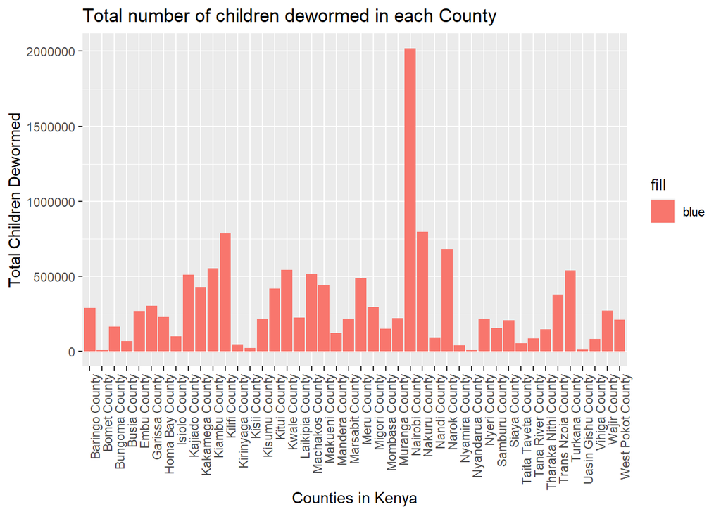

```r
county_group<- data%>%
group_by(county)%>%
summarise(sum_deworm=sum(Total.Dewormed))
ggplot(county_group, aes(x=county, y=sum_deworm, fill="blue"))+
 geom_col()+
  theme(axis.text.x = element_text(angle = 90, hjust = 1)) +
labs(x = "Counties in Kenya", y = "Total Children Dewormed", title = "Total number of children dewormed in each County")
```

**Malnutrition,stunted-growth, diarrhoea and underweight cases**

In relation to county we get to see their distribution

[figure not shown]

```r
#grouped by counties
# we use df dataset to prevent omission of some counties due to null values
#aggregations in respect to total cases
county_avg <- df %>%
          group_by(county) %>%
        summarise(
                  Acute.Malnutrition = sum(Acute.Malnutrition),
                  stunted.0..6.months = sum(stunted.0..6.months),
                  stunted.6.23.months = sum(stunted.6.23.months),
                  stunted.24.59.months = sum(stunted.24.59.months),
                  Underweight.0..6.months = sum(Underweight.0..6.months),
                  diarrhoea.cases = sum(diarrhoea.cases),
                  Underweight.6.23.months = sum(Underweight.6.23.months),
                 Underweight.24.59.Months = sum(Underweight.24.59.Months)
           )


#plot1
plot1 <- ggplot(county_avg, aes(x = county, y = Acute.Malnutrition, fill="blue")) +
                             geom_col() +
           theme(axis.text.x = element_text(angle = 90, hjust = 1)) +
                    labs(x = "Counties", y = "Total Malnutrition cases", title = "Total Acute Malnutrition Cases ")+coord_flip()
#plot2
plot2 <- ggplot(county_avg, aes(x = county, y = stunted.0..6.months)) +
                                  geom_col() +
                theme(axis.text.x = element_text(angle = 90, hjust = 1)) +
                        labs(x = "Counties", y = "Total stunted-growth cases", title = "  0-6months children with stunted growth ")

#plot5
 plot5 <- ggplot(county_avg, aes(x = county, y = diarrhoea.cases)) +
                                  geom_col() +
                     theme(axis.text.x = element_text(angle = 90, hjust = 1)) +
                              labs(x = "Counties", y = "Total Diarrhoes cases", title = "Diarrhoea cases across the Country ")
#plot6
plot6 <- ggplot(county_avg, aes(x = county, y = Underweight.0..6.months)) +
                                       geom_col() +
                     theme(axis.text.x = element_text(angle = 90, hjust = 1)) +
                              labs(x = "Counties", y = "Total cases", title = "Total Underweight children (0-<6months) ")
#plot7
 plot7 <- ggplot(county_avg, aes(x = county, y = Underweight.6.23.months)) +
                                            geom_col() +
                         theme(axis.text.x = element_text(angle = 90, hjust = 1))+
                                  labs(x = "Counties", y = "Total cases", title = "Total Underweight children (6-23months) ")
#plot3
 plot3 <- ggplot(county_avg, aes(x = county, y = stunted.6.23.months)) +
                                       geom_col() +
                     theme(axis.text.x = element_text(angle = 90, hjust = 1)) +
                             labs(x = "Counties", y = "Total cases", title = "6-23months children stunted-growth ")
#plot8
plot8 <- ggplot(county_avg, aes(x = county, y = Underweight.24.59.Months, width = 4, height = 4)) +
                                                 geom_col() +
                               theme(axis.text.x = element_text(angle = 90, hjust = 1)) +
                                      labs(x = "Counties", y = "Total cases", title = "Underweight children (24-59months) ")

#plot4
plot4 <- ggplot(county_avg, aes(x = county, y = stunted.24.59.months, fill="purple")) +
                                       geom_col() +
                     theme(axis.text.x = element_text(angle = 90, hjust = 1)) +
                        labs(x = "Counties", y = "Total cases", title = "(24-59)months stunted-growth ")

 #griding the subplots
grid.arrange(plot1, plot2,plot3,plot4, plot5, plot6, plot7, plot8, ncol = 1)
```

Notes:

- Nairobi county leads with diarrhoea and underweight cases of you children, despite having highest deworming rate. This leads us to another considerations of causes that might be due to hygiene challenges.
- Though Nairobi is also highly populated County.
- Wajir County leads in acute malnutrition cases, the emaciation might be considered as a result of drought and thus leads less food intake.
- Underweight cases of grown children mostly occcurs in Trans Nzoia, Turkana, Uasin Gishu counties.

**Rate of deworming in every month**

A new column of month

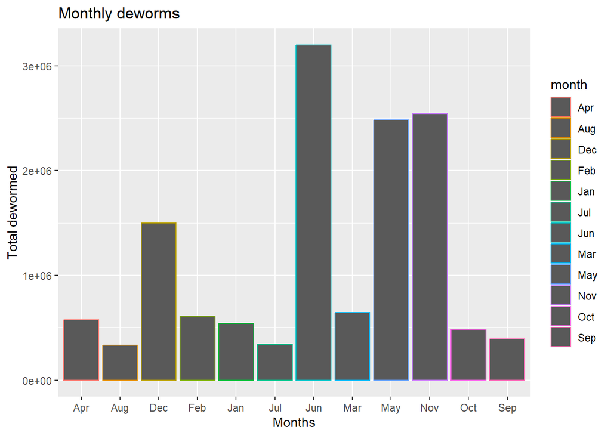

```r
data_split <- separate(data, period, into = c("month", "year"), sep = "-")
data_month<-data_split%>%
      group_by(month)%>%
      summarise(monthly_dewaormed=sum(Total.Dewormed))

ggplot(data_month, aes(x=month, y=monthly_dewaormed, color=month))+
 geom_col() +
          labs(x = "Months", y = "Total dewormed", title = "Monthly deworms ")
```

Most children were dewormed month of June.

May & Nov were slightly high.

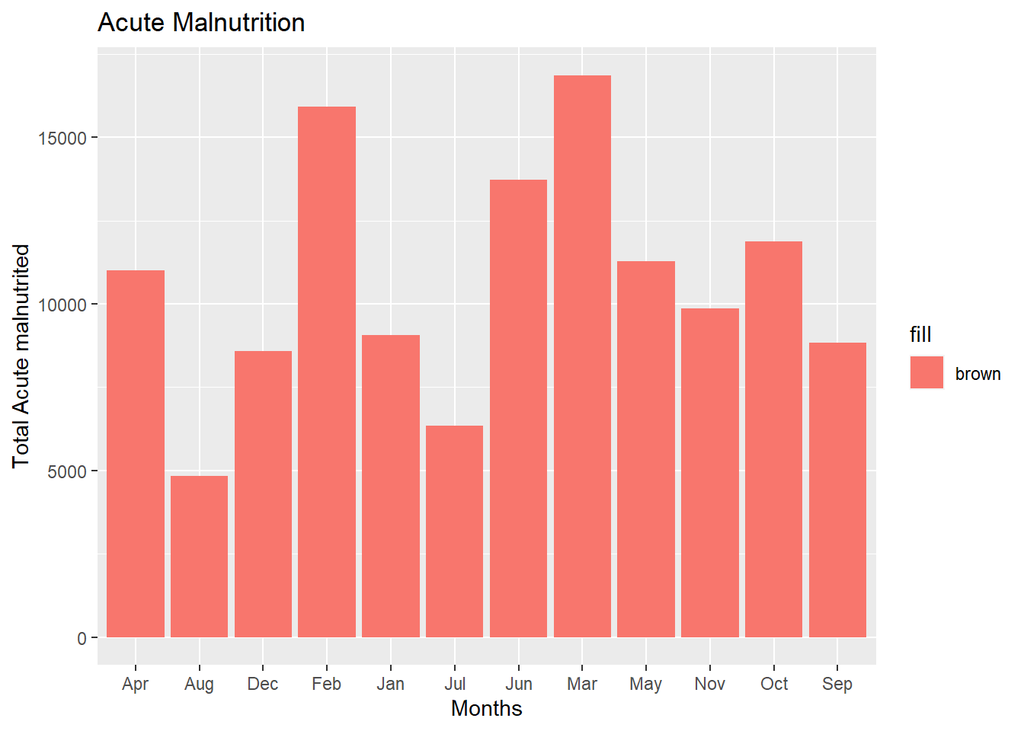

```r
data_month<-data_split%>%
      group_by(month)%>%
      summarise(monthly_malnutrition=sum(Acute.Malnutrition))

ggplot(data_month, aes(x=month, y=monthly_malnutrition, fill="brown"))+
 geom_col() +
          labs(x = "Months", y = "Total Acute malnutrited", title = "Acute Malnutrition" )
```

**Annual Deworming**

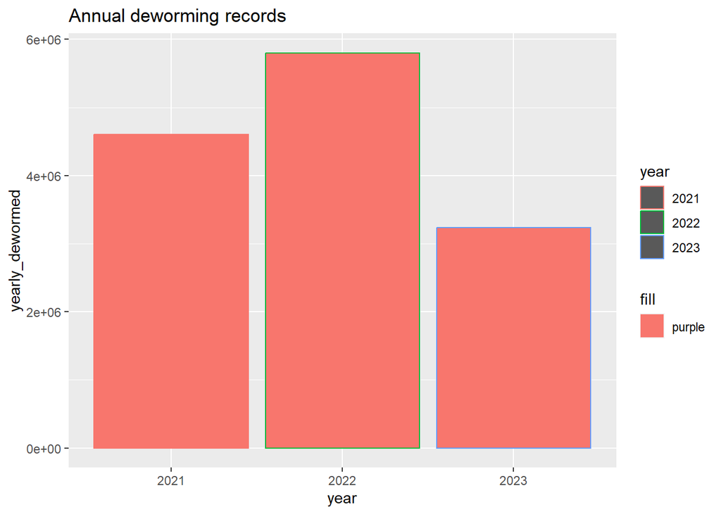

```r
data_yearly<-data_split%>%
      group_by(year)%>%
      summarise(yearly_dewormed=sum(Total.Dewormed))
data_yearly$year[data_yearly$year %in% c("21", "22", "23")] <- c("2021", "2022", "2023")
ggplot(data_yearly, aes(x=year, y=yearly_dewormed, color=year, fill="purple"))+
 geom_col()+labs(title = "Annual deworming records" )
```

Malnutrition

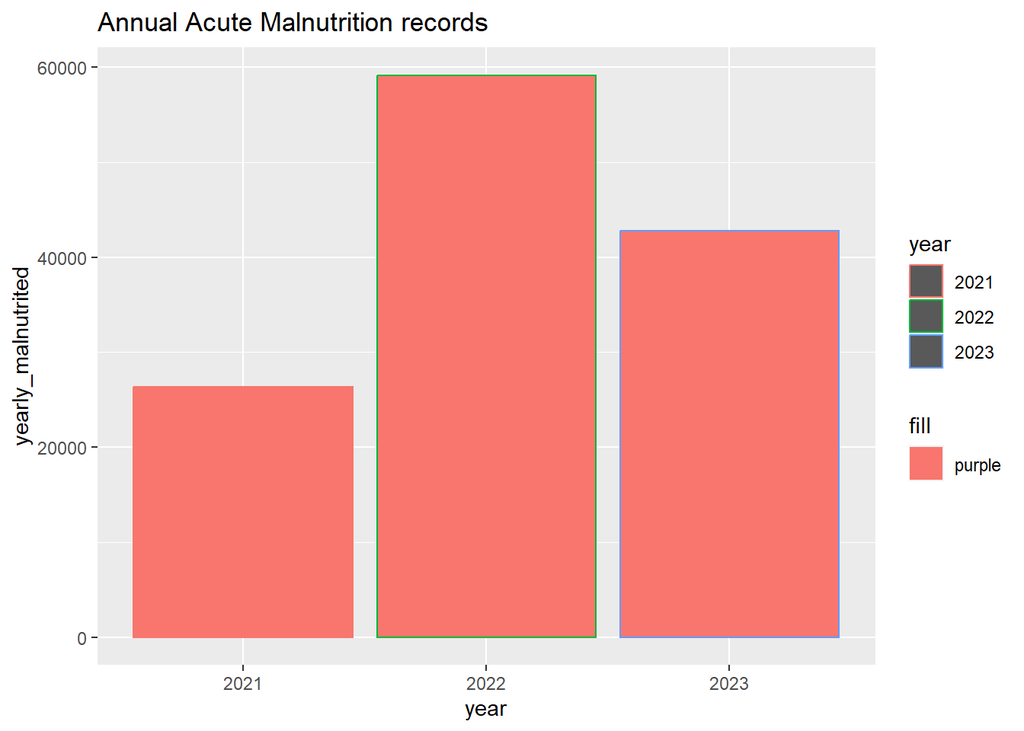

```r
data_yearly<-data_split%>%
      group_by(year)%>%
      summarise(yearly_malnutrited=sum(Acute.Malnutrition))
data_yearly$year[data_yearly$year %in% c("21", "22", "23")] <- c("2021", "2022", "2023")
ggplot(data_yearly, aes(x=year, y=yearly_malnutrited, color=year, fill="purple"))+
 geom_col()+labs(title = "Annual Acute Malnutrition records" )
```

2022 had high rate of Malnutrition followed by 2023 despite the year being half.

**Total.Dewormed vs Diarrhoea**

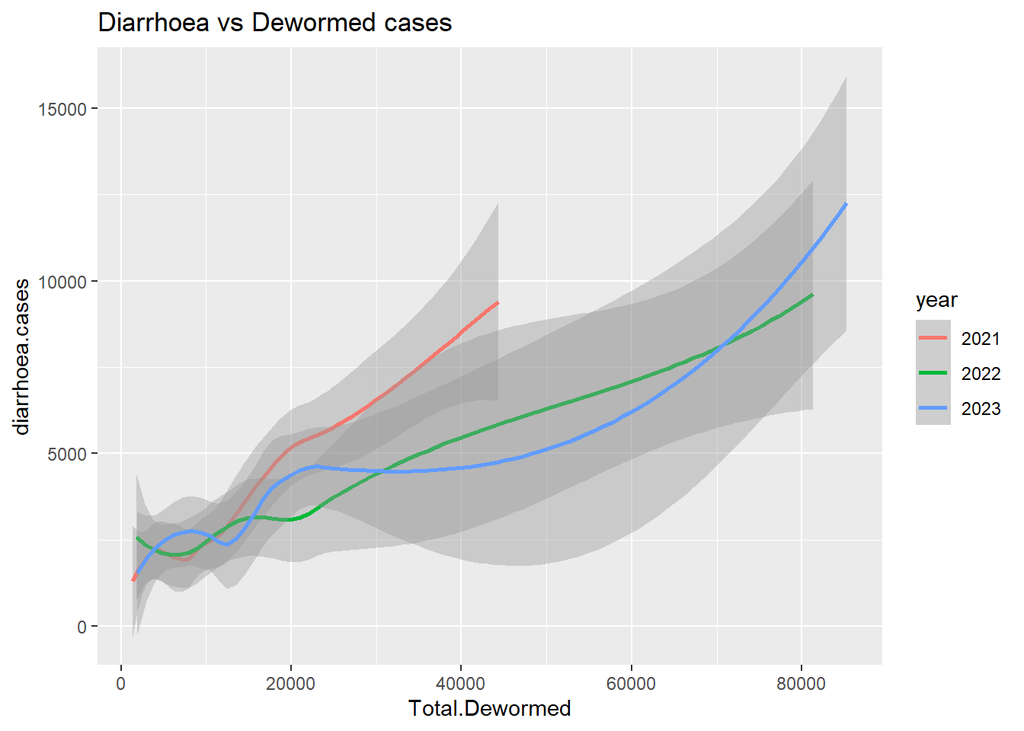

```r
# grouping dataset in county and year
yearly_avg <- data_split %>%
               group_by(county, year) %>%
               summarise(
                           Total.Dewormed=mean(Total.Dewormed),Acute.Malnutrition = mean(Acute.Malnutrition),
                           stunted.0..6.months = mean(stunted.0..6.months),
                           stunted.6.23.months = mean(stunted.6.23.months),
                           stunted.24.59.months = mean(stunted.24.59.months),
                           Underweight.0..6.months = mean(Underweight.0..6.months),
                           diarrhoea.cases = mean(diarrhoea.cases),
                           Underweight.6.23.months = mean(Underweight.6.23.months),
                           Underweight.24.59.Months =mean(Underweight.24.59.Months))
 #renaming the year values
yearly_avg$year[yearly_avg$year %in% c("21", "22", "23")] <- c("2021", "2022", "2023")
#plotting the data
ggplot(yearly_avg, aes(x=Total.Dewormed, y=diarrhoea.cases, color=year))+
     geom_smooth()+labs(title = "Diarrhoea vs Dewormed cases" )
```

There is a positive correlation between Total.dewormed and Diarrhoea cases.

Assumming that those places which had high rates of diarrhoea cases children were dewormed most.

**Total.Dewormed versus Stunted_Growth**

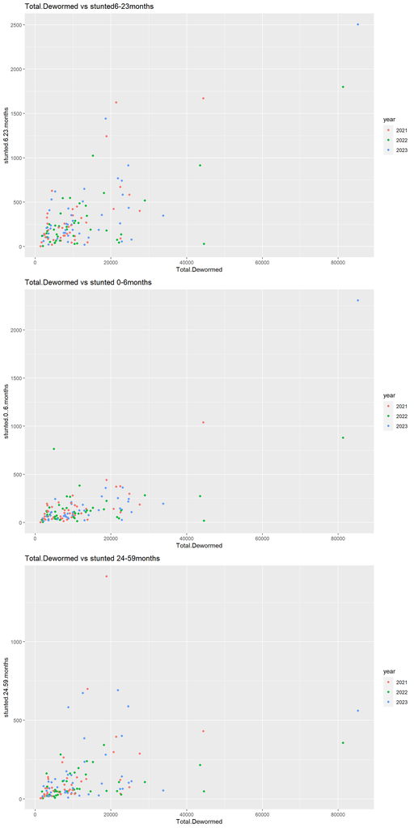

```r
p <- ggplot(yearly_avg, aes(x=Total.Dewormed, y=stunted.6.23.months, color=year))+
     geom_point()+labs(title = "Total.Dewormed vs stunted6-23months " )

pl <- ggplot(yearly_avg, aes(x=Total.Dewormed, y=stunted.0..6.months, color=year))+
     geom_point()+labs(title = "Total.Dewormed vs stunted 0-6months " )

plt <- ggplot(yearly_avg, aes(x=Total.Dewormed, y=stunted.24.59.months, color=year))+
     geom_point()+labs(title = "Total.Dewormed vs stunted 24-59months " )

grid.arrange(p, pl,plt, ncol = 1)
```

Linear correlation was noted from the graphs